# Структура научной презентации

Простейший шаблон

Кулябов Д. С.

Российский университет дружбы народов, Москва, Россия

Объединённый институт ядерных исследований, Дубна, Россия

# Информация

## Докладчик

- Казначеев Сергей Ильич
- Студент
- Российский университет дружбы народов
- [1132240693@pfur.ru]

# Цель

Изучить идеологию и применение средств контроля версий. Освоить умения по работе с git.

## Задачи

Создать базовую конфигурацию для работы с git. Создать ключ SSH.Создать ключ PGP. Настроить подписи git. Зарегистрироваться на Github. Создать локальный каталог для выполнения заданий по предмету.

## Установка Git

Для начала установим Git

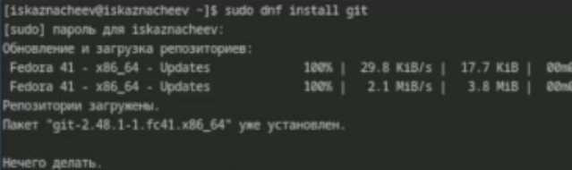

sc1

## Установка gh

Теперь установим gh

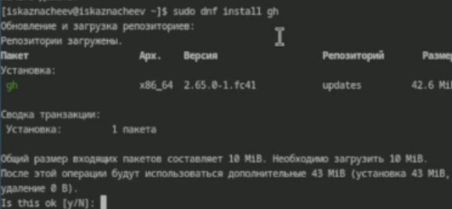

sc2

## Настройки git

Далее задаем имя владельца репозитория

## Настройки git

Далее задаем почту владельца git

## Настройки git

Далее настроим котировку UTF-8 в выводе сообщения git

## Настройки git

Зададим имя начальной ветки настроим параметры autocrlf и safecrlf

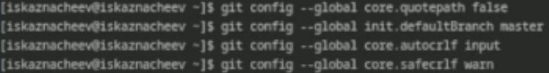

sc4

## Создание ключа ssh

Создадим ключ RSA размером 4096 бит

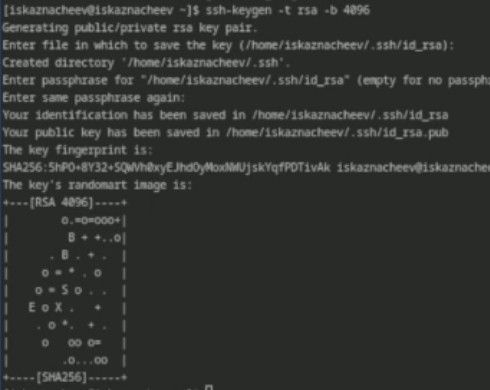

sc5

## Создание ключа ssh

Теперь создаем ключ по алгоритму ed22519

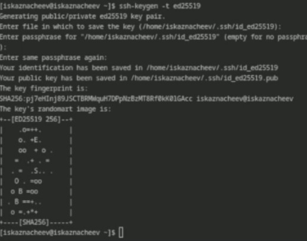

sc6

## Создание ключа gpg

Теперь создаем gpg, выбираем из предложенных вариантов первый тим(тип RSA and RSA),размер 4096 бит и делаем срок ключа неограниченным

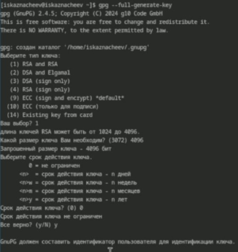

sc7

## Создание ключа gpg

После нас просят ввести свои данные. Мы вводим имя и адрес электронной почты. После этого соглашаемся с генерацией ключа

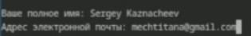

sc8

## Добавляем GPG ключ на Github

Далее выводим список ключей gpg

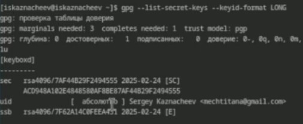

sc9

## Добавляем GPG ключ на Github

Копируем наш ключ в буфер обмена

## Добавляем GPG ключ на Github

Вставляем ключ на Github и задаем ему имя

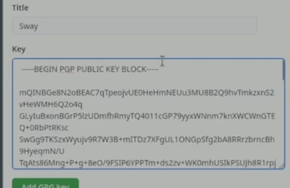

sc11

## Настройка автоматических подписей коммитов git

Теперь произведем автоматическую настройку подписей

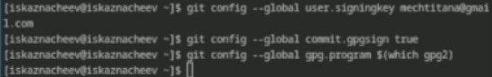

sc12

## Настройка gh

После нам нужно авторизироватся в github с помощью gh. Мы выбираем сайт для авторизации(Github),после выбираем предпочитаемый протокол (SSH), публичный ключ SSH ключ (id_rsa.pub) и имя для ключа sway. В качестве способа авторизации выбираем авторизацию через браузер

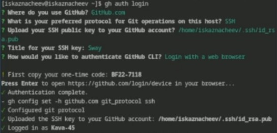

sc13

## Создание репозитория курса на основе шаблона

Теперь создаем рабочую директорию курса и переходим в неё

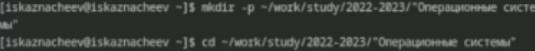

sc14

## Создание репозитория курса на основе шаблона

Создаем репозиторий для лабораторных работ из шаблона

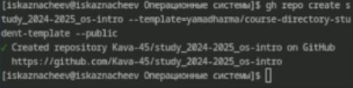

sc15

## Создание репозитория курса на основе шаблона

И клонируем его к себе на компьютер

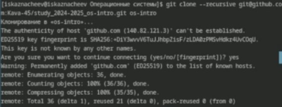

sc16

## Настройка каталога курса

Переходим в него с помощью cd и удаляем файл(package.json) и создаем необходимые каталоги записав в файл COURSE строку echo os-intro и прописываем make prepare для того, чтобы нужные нам каталоги создались

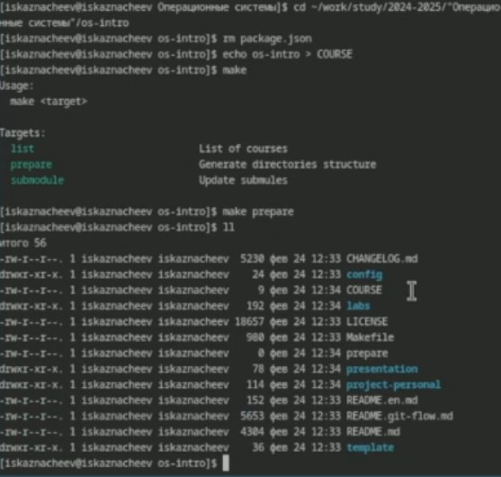

sc17

## Настройка каталога курса

Теперь добавляем нашу папку для отправки

## Настройка каталога курса

Делаем коммит в котором указываем что мы сделали структуру курса

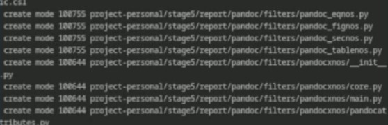

sc19

## Настройка каталога курса

И отправляем файлы на Github с помощью команды push

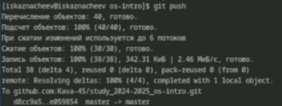

sc20

## Вывод

Я изучил идеологию и применение средств контроля версий и освоил умения по работе с git